# Homework 05

Author

Ziqi Zhang (ziqiz13)

## Question 1: Estimate the bias and variance of KNN

I used equal neighbor weights and Euclidean distance throughout this question. The seeds were **43201** for part (a) and **432011** for the independent simulation in part (b).

### (a)

At $\mathbf x_0=(0.5,0.7,1)^\mathsf T$,

$$f(\mathbf x_0)=0.5(0.5)+\sin(0.7)-0.3(1)^2
=\sin(0.7)-0.05.$$

**Show the workflow**

```python
def regression_mean(X):
    """Conditional response mean used in Questions 1 and 2."""
    return 0.5 * X[:, 0] + np.sin(X[:, 1]) - 0.3 * X[:, 2] ** 2


x0 = np.array([[0.5, 0.7, 1.0]])
truth_q1 = regression_mean(x0)[0]
k_q1 = np.arange(1, 30, 2)

rng_q1a = np.random.default_rng(43201)
X_train_q1a = rng_q1a.normal(size=(400, 3))
y_train_q1a = regression_mean(X_train_q1a) + rng_q1a.normal(scale=0.1, size=400)

pred_one = []
for k in k_q1:
    fit = KNeighborsRegressor(n_neighbors=k, weights="uniform", metric="euclidean")
    fit.fit(X_train_q1a, y_train_q1a)
    pred_one.append(fit.predict(x0)[0])

print(f"f(x0) = {truth_q1:.6f}")
pd.DataFrame({"k": k_q1, "KNN prediction": pred_one})
```

```
f(x0) = 0.594218
```

|  | k | KNN prediction |
| --- | --- | --- |
| 0 | 1 | 0.509096 |
| 1 | 3 | 0.478362 |
| 2 | 5 | 0.531111 |
| 3 | 7 | 0.513569 |
| 4 | 9 | 0.463513 |
| 5 | 11 | 0.506585 |
| 6 | 13 | 0.453129 |
| 7 | 15 | 0.490525 |
| 8 | 17 | 0.496576 |
| 9 | 19 | 0.411351 |
| 10 | 21 | 0.452147 |
| 11 | 23 | 0.455313 |
| 12 | 25 | 0.418699 |
| 13 | 27 | 0.486101 |
| 14 | 29 | 0.456503 |

### (b)

In every repetition I generated a new set of covariates and errors, and I reused that same training set for all 15 choices of $k$.

**Show the workflow**

```python
rng_q1b = np.random.default_rng(432011)
pred_matrix = np.empty((200, len(k_q1)))

for b in range(200):
    X_b = rng_q1b.normal(size=(400, 3))
    y_b = regression_mean(X_b) + rng_q1b.normal(scale=0.1, size=400)
    # One neighbor search supplies the ordered neighbors for every k.
    sq_dist = np.sum((X_b - x0) ** 2, axis=1)
    order = np.argsort(sq_dist, kind="stable")
    cumulative_y = np.cumsum(y_b[order])
    pred_matrix[b, :] = cumulative_y[k_q1 - 1] / k_q1

mean_pred = pred_matrix.mean(axis=0)
bias = mean_pred - truth_q1
sq_bias = bias**2
# ddof=0 gives divisor 200, as requested.
variance = pred_matrix.var(axis=0, ddof=0)
mse = np.mean((pred_matrix - truth_q1) ** 2, axis=0)
identity_error = mse - (sq_bias + variance)

q1_summary = pd.DataFrame(
    {
        "k": k_q1,
        "bias": bias,
        "squared bias": sq_bias,
        "variance": variance,
        "MSE": mse,
        "MSE - (bias^2 + variance)": identity_error,
    }
)
q1_summary
```

|  | k | bias | squared bias | variance | MSE | MSE - (bias^2 + variance) |
| --- | --- | --- | --- | --- | --- | --- |
| 0 | 1 | -0.028442 | 0.000809 | 0.036795 | 0.037604 | 2.081668e-17 |
| 1 | 3 | -0.028085 | 0.000789 | 0.017704 | 0.018492 | -1.734723e-17 |
| 2 | 5 | -0.040740 | 0.001660 | 0.016066 | 0.017726 | 1.387779e-17 |
| 3 | 7 | -0.051732 | 0.002676 | 0.011504 | 0.014180 | 8.673617e-18 |
| 4 | 9 | -0.054939 | 0.003018 | 0.010370 | 0.013389 | -1.561251e-17 |
| 5 | 11 | -0.059841 | 0.003581 | 0.010725 | 0.014306 | 1.040834e-17 |
| 6 | 13 | -0.068294 | 0.004664 | 0.009741 | 0.014405 | 1.040834e-17 |
| 7 | 15 | -0.076223 | 0.005810 | 0.009030 | 0.014840 | -1.387779e-17 |
| 8 | 17 | -0.080933 | 0.006550 | 0.008772 | 0.015322 | 7.285839e-17 |
| 9 | 19 | -0.085403 | 0.007294 | 0.008506 | 0.015799 | -2.428613e-17 |
| 10 | 21 | -0.092161 | 0.008494 | 0.008247 | 0.016740 | 2.428613e-17 |
| 11 | 23 | -0.100925 | 0.010186 | 0.008326 | 0.018512 | -3.816392e-17 |
| 12 | 25 | -0.106586 | 0.011360 | 0.007461 | 0.018821 | 3.469447e-18 |
| 13 | 27 | -0.112970 | 0.012762 | 0.007526 | 0.020288 | 2.428613e-17 |
| 14 | 29 | -0.121349 | 0.014726 | 0.007044 | 0.021769 | -7.979728e-17 |

The largest absolute numerical discrepancy in the requested identity is 7.980e-17, which is just floating-point roundoff.

**Show the workflow**

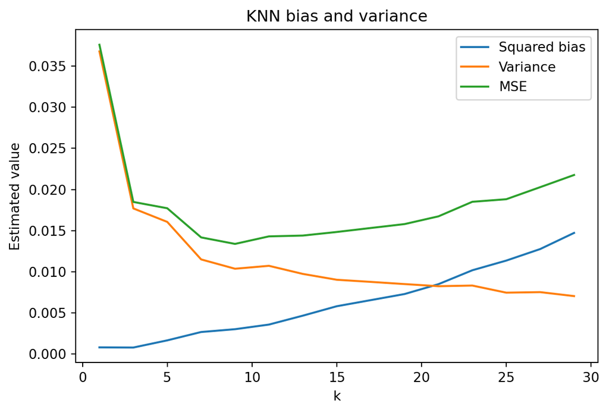

Original bias–variance plot.

```python
plt.figure(figsize=(7, 4.5))
plt.plot(k_q1, sq_bias, label="Squared bias")
plt.plot(k_q1, variance, label="Variance")
plt.plot(k_q1, mse, label="MSE")
plt.xlabel("k")
plt.ylabel("Estimated value")
plt.title("KNN bias and variance")
plt.legend()
plt.show()
```

Variance falls as $k$ grows because averaging more responses makes the fit less sensitive to the particular training sample. Squared bias generally rises because larger neighborhoods average observations whose covariates are farther from $\mathbf x_0$. Consequently, MSE is minimized at an intermediate amount of smoothing in this run. This is the same qualitative trade-off as ridge or lasso: stronger regularization usually increases bias and reduces variance. Here, larger $k$ is the stronger smoothing choice, whereas larger $\lambda$ is the stronger penalty for ridge or lasso.

## Question 2: Compare KNN with lasso

I used seed **43202**. Within each setting, KNN and lasso used exactly the same training and test observations. Test MSE is computed against the generated noisy test responses.

**Show the workflow**

```python
lambda_grid = np.logspace(-4, 0, 41)


def lasso_cv_train_predict(X_train, y_train, X_test, seed):
    """Ten-fold CV with transformations estimated inside each training fold."""
    folds = KFold(n_splits=10, shuffle=True, random_state=seed)
    cv_mse = np.zeros(len(lambda_grid))

    for train_idx, valid_idx in folds.split(X_train):
        X_fold = X_train[train_idx]
        y_fold = y_train[train_idx]
        x_mean = X_fold.mean(axis=0)
        x_scale = X_fold.std(axis=0, ddof=0)
        y_mean = y_fold.mean()
        X_fold_std = (X_fold - x_mean) / x_scale
        X_valid_std = (X_train[valid_idx] - x_mean) / x_scale
        y_fold_centered = y_fold - y_mean

        for j, lam in enumerate(lambda_grid):
            model = Lasso(alpha=lam, fit_intercept=False, max_iter=20000, tol=1e-8)
            model.fit(X_fold_std, y_fold_centered)
            valid_pred = y_mean + X_valid_std @ model.coef_
            cv_mse[j] += np.mean((y_train[valid_idx] - valid_pred) ** 2) / 10

    best_index = np.argmin(cv_mse)
    best_lambda = lambda_grid[best_index]

    # Re-estimate every transformation using all training observations.
    x_mean = X_train.mean(axis=0)
    x_scale = X_train.std(axis=0, ddof=0)
    y_mean = y_train.mean()
    X_train_std = (X_train - x_mean) / x_scale
    X_test_std = (X_test - x_mean) / x_scale
    final_model = Lasso(
        alpha=best_lambda, fit_intercept=False, max_iter=20000, tol=1e-8
    )
    final_model.fit(X_train_std, y_train - y_mean)
    test_pred = y_mean + X_test_std @ final_model.coef_
    return test_pred, best_lambda, final_model.coef_, cv_mse


def make_q2_data(rng, correlated):
    if correlated:
        Sigma = np.full((30, 30), 0.8)
        np.fill_diagonal(Sigma, 1.0)
        X_train = rng.multivariate_normal(np.zeros(30), Sigma, size=400)
        X_test = rng.multivariate_normal(np.zeros(30), Sigma, size=1000)
    else:
        X_train = rng.normal(size=(400, 30))
        X_test = rng.normal(size=(1000, 30))
    y_train = regression_mean(X_train) + rng.normal(scale=0.1, size=400)
    y_test = regression_mean(X_test) + rng.normal(scale=0.1, size=1000)
    return X_train, y_train, X_test, y_test
```

**Show the workflow**

```python
rng_q2 = np.random.default_rng(43202)
q2_rows = []
q2_details = {}

for setting, correlated in [("Independent", False), ("Correlation 0.8", True)]:
    X_train, y_train, X_test, y_test = make_q2_data(rng_q2, correlated)

    knn = KNeighborsRegressor(n_neighbors=5, weights="uniform", metric="euclidean")
    knn.fit(X_train, y_train)
    pred_knn = knn.predict(X_test)

    pred_lasso, selected_lambda, coef, cv_mse = lasso_cv_train_predict(
        X_train, y_train, X_test, seed=43202
    )
    q2_rows.extend(
        [
            {
                "setting": setting,
                "method": "5NN",
                "test MSE": np.mean((y_test - pred_knn) ** 2),
                "selected lambda": np.nan,
                "nonzero lasso slopes": np.nan,
            },
            {
                "setting": setting,
                "method": "Lasso",
                "test MSE": np.mean((y_test - pred_lasso) ** 2),
                "selected lambda": selected_lambda,
                "nonzero lasso slopes": np.count_nonzero(np.abs(coef) > 1e-8),
            },
        ]
    )
    q2_details[setting] = {
        "y_test": y_test,
        "knn": pred_knn,
        "lasso": pred_lasso,
        "coef": coef,
        "cv_mse": cv_mse,
    }

q2_results = pd.DataFrame(q2_rows)
q2_results
```

|  | setting | method | test MSE | selected lambda | nonzero lasso slopes |
| --- | --- | --- | --- | --- | --- |
| 0 | Independent | 5NN | 0.543331 | NaN | NaN |
| 1 | Independent | Lasso | 0.251601 | 0.063096 | 2.0 |
| 2 | Correlation 0.8 | 5NN | 0.193937 | NaN | NaN |
| 3 | Correlation 0.8 | Lasso | 0.366291 | 0.019953 | 7.0 |

### (b)

With independent nuisance covariates, the Euclidean distance contains 27 noise directions that do not help predict the response. Their accumulated differences can overwhelm proximity in the first three useful directions, so the nearest points in 30-dimensional space need not have similar conditional means. Under strong positive correlation, the 30 coordinates share substantial common movement. Distances then contain more redundant information and the effective geometry can be lower dimensional, which can make neighborhoods more informative in this particular simulation.

Lasso treats coordinates differently: it estimates a separate slope and can set a slope exactly to zero. KNN has no analogous variable-selection step; every supplied coordinate contributes a squared difference to Euclidean distance. Correlation can also make the lasso’s choice among correlated variables less stable because several variables can carry similar linear information, but it still need not retain all 30.

### (c)

The true regression surface is nonlinear in $X_2$ and $X_3$, whereas the fitted lasso is restricted to a hyperplane. In particular, a centered Gaussian variable has no population linear association with its square, so a linear-only lasso cannot represent the $-0.3X_3^2$ component directly. KNN can adapt locally to both nonlinear terms, but pays for distance calculations in all 30 coordinates. Thus the comparison mixes two effects: nonlinear flexibility favors KNN, while sparsity and dimension reduction favor lasso. These two generated datasets cannot justify a universal claim that correlation always helps KNN or that either method is always better. The result depends on the covariance structure, sample size, signal, irrelevant variables, noise, tuning, and form of the regression function.

## Question 3: Observed dimension and latent dimension

I used seed **43203** for the one-dataset comparison and seed **432031** for the 50-repetition experiment.

**Show the workflow**

```python
k_q3 = np.arange(2, 83, 8)


def make_q3_data(rng, m, n_train=200, n_test=200):
    A = rng.uniform(-2, 2, size=(100, m))
    Z_train = rng.normal(size=(n_train, m))
    Z_test = rng.normal(size=(n_test, m))
    X_train = Z_train @ A.T + rng.normal(size=(n_train, 100))
    X_test = Z_test @ A.T + rng.normal(size=(n_test, 100))
    y_train = Z_train[:, 0] + Z_train[:, 1] + rng.normal(size=n_train)
    y_test = Z_test[:, 0] + Z_test[:, 1] + rng.normal(size=n_test)
    return X_train, y_train, X_test, y_test


def knn_mse_for_k(X_train, y_train, X_test, y_test, k_values):
    # Squared distances preserve the same ordering as Euclidean distances.
    sq_dist = (
        np.sum(X_test**2, axis=1)[:, None]
        + np.sum(X_train**2, axis=1)[None, :]
        - 2 * X_test @ X_train.T
    )
    neighbor_order = np.argsort(sq_dist, axis=1, kind="stable")
    ordered_y = y_train[neighbor_order]
    cumulative_y = np.cumsum(ordered_y, axis=1)
    return np.array(
        [np.mean((y_test - cumulative_y[:, k - 1] / k) ** 2) for k in k_values]
    )
```

### (a)

**Show the workflow**

```python
rng_q3a = np.random.default_rng(43203)
q3_single = []
for m in (3, 30):
    data = make_q3_data(rng_q3a, m)
    mse_values = knn_mse_for_k(*data, k_q3)
    q3_single.append(pd.DataFrame({"m": m, "k": k_q3, "test MSE": mse_values}))

q3_single_table = pd.concat(q3_single, ignore_index=True).pivot(
    index="k", columns="m", values="test MSE"
)
q3_single_table.columns = [f"m = {m}" for m in q3_single_table.columns]
q3_single_table
```

| k | m = 3 | m = 30 |
| --- | --- | --- |
| 2 | 1.861896 | 2.932901 |
| 10 | 1.514737 | 2.328745 |
| 18 | 1.565656 | 2.256019 |
| 26 | 1.622996 | 2.308517 |
| 34 | 1.729244 | 2.297538 |
| 42 | 1.819946 | 2.332075 |
| 50 | 1.897799 | 2.391882 |
| 58 | 1.975742 | 2.446488 |
| 66 | 2.025353 | 2.463940 |
| 74 | 2.102502 | 2.505887 |
| 82 | 2.174974 | 2.555903 |

### (b)

**Show the workflow**

```python
rng_q3b = np.random.default_rng(432031)
q3_repeated = {3: np.empty((50, len(k_q3))), 30: np.empty((50, len(k_q3)))}

for b in range(50):
    for m in (3, 30):
        data = make_q3_data(rng_q3b, m)
        q3_repeated[m][b] = knn_mse_for_k(*data, k_q3)

q3_average = pd.DataFrame(
    {"k": k_q3, "m = 3": q3_repeated[3].mean(axis=0), "m = 30": q3_repeated[30].mean(axis=0)}
)
q3_average
```

|  | k | m = 3 | m = 30 |
| --- | --- | --- | --- |
| 0 | 2 | 1.647906 | 3.112654 |
| 1 | 10 | 1.280505 | 2.352900 |
| 2 | 18 | 1.305695 | 2.359970 |
| 3 | 26 | 1.350042 | 2.384387 |
| 4 | 34 | 1.403572 | 2.419343 |
| 5 | 42 | 1.458954 | 2.447953 |
| 6 | 50 | 1.519993 | 2.485701 |
| 7 | 58 | 1.578565 | 2.513998 |
| 8 | 66 | 1.636910 | 2.544010 |
| 9 | 74 | 1.696845 | 2.576658 |
| 10 | 82 | 1.759460 | 2.607724 |

**Show the workflow**

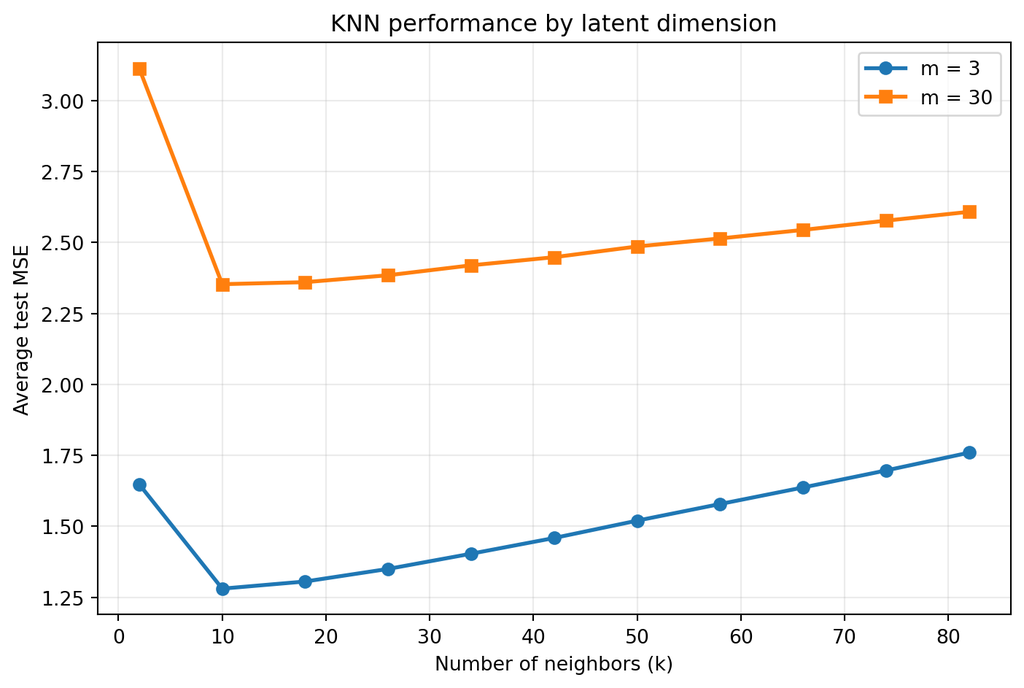

Average test MSE over 50 complete experiments.

```python
fig, ax = plt.subplots(figsize=(7.2, 4.8), layout="constrained")
ax.plot(k_q3, q3_average["m = 3"], marker="o", linewidth=2, label="m = 3")
ax.plot(k_q3, q3_average["m = 30"], marker="s", linewidth=2, label="m = 30")
ax.set(title="KNN performance by latent dimension", xlabel="Number of neighbors (k)", ylabel="Average test MSE")
ax.grid(alpha=0.25)
ax.legend()
plt.show()
```

### (c)

Observed dimension alone does not determine KNN difficulty. When $m=3$, most systematic variation in the 100 measurements is driven by three shared latent coordinates. Euclidean closeness in $X$ is therefore more likely to imply closeness in the response-relevant $Z_1$ and $Z_2$. When $m=30$, distance also reflects many more latent directions unrelated to $Y$; these directions can dominate the neighbor ranking even though the response still uses only two latent variables.

The vector $\boldsymbol\eta_i$ adds independent noise to every observed coordinate. It inflates and perturbs pairwise distances, so even two observations with similar latent values can look separated in $X$. Because this noise has support throughout $\mathbb R^{100}$, observations are not exactly on the $m$-dimensional column space of $A$; they form a noisy cloud around it. This explains why lower latent dimension helps without making the problem equivalent to noiseless KNN in $m$ dimensions.

## Question 4: Classify handwritten digits

No random sampling or randomized fitting is used in this question. I used the first 1,000 training rows and first 500 test rows as specified.

**Show the workflow**

```python
data_dir = Path("data/knn")
train_digits = pd.read_csv(data_dir / "zip-train.csv.gz", header=None).iloc[:1000]
test_digits = pd.read_csv(data_dir / "zip-test.csv.gz", header=None).iloc[:500]

y_digit_train = train_digits.iloc[:, 0].to_numpy(dtype=int)
X_digit_train = train_digits.iloc[:, 1:].to_numpy(dtype=float)
y_digit_test = test_digits.iloc[:, 0].to_numpy(dtype=int)
X_digit_test = test_digits.iloc[:, 1:].to_numpy(dtype=float)

print("Training shape:", X_digit_train.shape)
print("Test shape:", X_digit_test.shape)
```

```
Training shape: (1000, 256)
Test shape: (500, 256)
```

### (a)

The function below computes every distance directly. `np.lexsort` uses distance as the primary key and training row number as the secondary key. `np.argmax` applied to the counts returns the smallest label when vote counts tie.

**Show the workflow**

```python
def classify_5nn(X_train, y_train, X_test, distance="euclidean"):
    predictions = np.empty(X_test.shape[0], dtype=int)
    train_row = np.arange(X_train.shape[0])

    for i, x0_i in enumerate(X_test):
        differences = X_train - x0_i
        if distance == "euclidean":
            distances = np.sqrt(np.sum(differences**2, axis=1))
        elif distance == "manhattan":
            distances = np.sum(np.abs(differences), axis=1)
        else:
            raise ValueError("distance must be 'euclidean' or 'manhattan'")

        nearest_five = np.lexsort((train_row, distances))[:5]
        vote_counts = np.bincount(y_train[nearest_five], minlength=10)
        predictions[i] = np.argmax(vote_counts)

    return predictions
```

### (b)

**Show the workflow**

```python
pred_euclidean = classify_5nn(
    X_digit_train, y_digit_train, X_digit_test, distance="euclidean"
)
pred_manhattan = classify_5nn(
    X_digit_train, y_digit_train, X_digit_test, distance="manhattan"
)


def confusion_predicted_rows(y_true, y_pred):
    return pd.crosstab(
        pd.Categorical(y_pred, categories=range(10)),
        pd.Categorical(y_true, categories=range(10)),
        rownames=["predicted"],
        colnames=["true"],
        dropna=False,
    )


error_euclidean = np.mean(pred_euclidean != y_digit_test)
error_manhattan = np.mean(pred_manhattan != y_digit_test)
cm_euclidean = confusion_predicted_rows(y_digit_test, pred_euclidean)
cm_manhattan = confusion_predicted_rows(y_digit_test, pred_manhattan)

pd.DataFrame(
    {
        "distance": ["Euclidean", "Manhattan"],
        "classification error": [error_euclidean, error_manhattan],
        "number incorrect": [
            np.sum(pred_euclidean != y_digit_test),
            np.sum(pred_manhattan != y_digit_test),
        ],
    }
)
```

|  | distance | classification error | number incorrect |
| --- | --- | --- | --- |
| 0 | Euclidean | 0.122 | 61 |
| 1 | Manhattan | 0.138 | 69 |

**Euclidean confusion matrix (predicted rows, true columns):**

**Show the workflow**

```python
cm_euclidean
```

| true predicted | 0 | 1 | 2 | 3 | 4 | 5 | 6 | 7 | 8 | 9 |
| --- | --- | --- | --- | --- | --- | --- | --- | --- | --- | --- |
| 0 | 118 | 0 | 7 | 1 | 0 | 4 | 2 | 0 | 2 | 0 |
| 1 | 0 | 66 | 0 | 0 | 2 | 0 | 0 | 0 | 0 | 1 |
| 2 | 0 | 0 | 39 | 1 | 0 | 0 | 2 | 0 | 0 | 1 |
| 3 | 0 | 0 | 0 | 23 | 0 | 4 | 0 | 0 | 2 | 0 |
| 4 | 0 | 0 | 1 | 0 | 27 | 1 | 1 | 1 | 0 | 1 |
| 5 | 0 | 0 | 0 | 1 | 0 | 13 | 0 | 0 | 0 | 0 |
| 6 | 0 | 2 | 0 | 0 | 0 | 1 | 41 | 0 | 2 | 0 |
| 7 | 0 | 0 | 0 | 0 | 1 | 1 | 0 | 34 | 0 | 4 |
| 8 | 0 | 0 | 3 | 2 | 0 | 2 | 0 | 0 | 37 | 0 |
| 9 | 1 | 0 | 0 | 1 | 4 | 0 | 0 | 1 | 1 | 41 |

**Manhattan confusion matrix (predicted rows, true columns):**

**Show the workflow**

```python
cm_manhattan
```

| true predicted | 0 | 1 | 2 | 3 | 4 | 5 | 6 | 7 | 8 | 9 |
| --- | --- | --- | --- | --- | --- | --- | --- | --- | --- | --- |
| 0 | 118 | 0 | 6 | 1 | 0 | 5 | 3 | 0 | 4 | 0 |
| 1 | 0 | 67 | 2 | 0 | 2 | 0 | 1 | 0 | 0 | 1 |
| 2 | 0 | 0 | 35 | 0 | 0 | 0 | 2 | 0 | 0 | 0 |
| 3 | 0 | 0 | 1 | 24 | 0 | 4 | 0 | 0 | 2 | 0 |
| 4 | 0 | 0 | 1 | 1 | 27 | 1 | 0 | 1 | 0 | 1 |
| 5 | 0 | 0 | 0 | 1 | 0 | 11 | 0 | 0 | 0 | 0 |
| 6 | 0 | 1 | 0 | 0 | 0 | 2 | 40 | 0 | 2 | 0 |
| 7 | 0 | 0 | 2 | 1 | 1 | 0 | 0 | 34 | 0 | 5 |
| 8 | 0 | 0 | 2 | 0 | 0 | 3 | 0 | 0 | 34 | 0 |
| 9 | 1 | 0 | 1 | 1 | 4 | 0 | 0 | 1 | 2 | 41 |

**Show the workflow**

```python
def largest_directed_confusions(cm, n=6):
    entries = []
    values = cm.to_numpy()
    for predicted in range(10):
        for true in range(10):
            if predicted != true and values[predicted, true] > 0:
                entries.append((values[predicted, true], true, predicted))
    entries.sort(reverse=True)
    return pd.DataFrame(entries[:n], columns=["count", "true digit", "predicted digit"])


print("Largest Euclidean off-diagonal cells:")
display(largest_directed_confusions(cm_euclidean))
print("Largest Manhattan off-diagonal cells:")
display(largest_directed_confusions(cm_manhattan))
```

```
Largest Euclidean off-diagonal cells:
```

|  | count | true digit | predicted digit |
| --- | --- | --- | --- |
| 0 | 7 | 2 | 0 |
| 1 | 4 | 9 | 7 |
| 2 | 4 | 5 | 3 |
| 3 | 4 | 5 | 0 |
| 4 | 4 | 4 | 9 |
| 5 | 3 | 2 | 8 |

```
Largest Manhattan off-diagonal cells:
```

|  | count | true digit | predicted digit |
| --- | --- | --- | --- |
| 0 | 6 | 2 | 0 |
| 1 | 5 | 9 | 7 |
| 2 | 5 | 5 | 0 |
| 3 | 4 | 8 | 0 |
| 4 | 4 | 5 | 3 |
| 5 | 4 | 4 | 9 |

The largest off-diagonal cells above identify the digit pairs most often confused in each direction. This is more informative than relying on the overall error alone, because a confusion from true 5 to predicted 3 is distinct from the reverse.

### (c)

**Show the workflow**

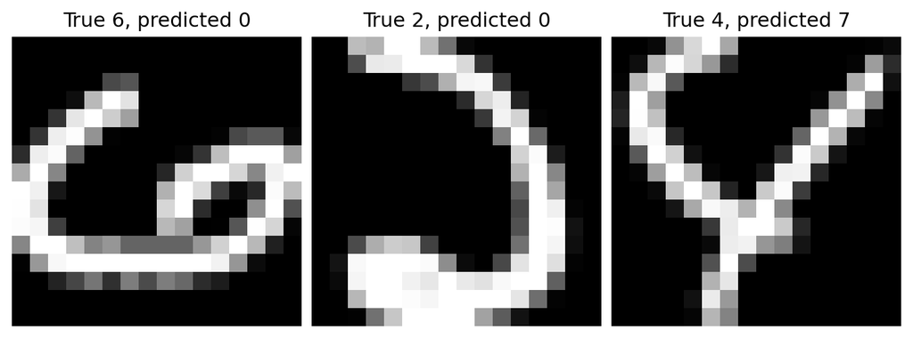

Three Euclidean 5NN mistakes; white pixels have larger original values.

```python
wrong_euclidean = np.flatnonzero(pred_euclidean != y_digit_test)
chosen = wrong_euclidean[:3]

fig, axes = plt.subplots(1, 3, figsize=(7.5, 2.8), layout="constrained")
for ax, index in zip(axes, chosen):
    ax.imshow(X_digit_test[index].reshape(16, 16), cmap="gray", origin="upper")
    ax.set_title(f"True {y_digit_test[index]}, predicted {pred_euclidean[index]}")
    ax.axis("off")
plt.show()
```

Some errors are visually understandable because the writing is faint, distorted, or shares strokes with the predicted class; the displayed cases allow that judgment to be checked rather than inferred only from counts.

**Show the workflow**

```python
wrong_e = pred_euclidean != y_digit_test
wrong_m = pred_manhattan != y_digit_test
error_overlap = pd.DataFrame(
    {
        "comparison": [
            "wrong under both",
            "wrong only under Euclidean",
            "wrong only under Manhattan",
            "different predicted labels",
        ],
        "number of test images": [
            np.sum(wrong_e & wrong_m),
            np.sum(wrong_e & ~wrong_m),
            np.sum(~wrong_e & wrong_m),
            np.sum(pred_euclidean != pred_manhattan),
        ],
    }
)
error_overlap
```

|  | comparison | number of test images |
| --- | --- | --- |
| 0 | wrong under both | 58 |
| 1 | wrong only under Euclidean | 3 |
| 2 | wrong only under Manhattan | 11 |
| 3 | different predicted labels | 22 |

The overlap table confirms that two distances can have similar total error while making mistakes on different images. Euclidean distance emphasizes a few large pixel differences through squaring, whereas Manhattan distance accumulates pixel differences linearly. These distinct geometries can change the five selected neighbors even when their final aggregate error rates are close.

## Question 5: Create a plot-formatting skill

### (a)

I created and installed an explicit-only skill named `stat432-plot-formatting`. Its description confines it to STAT 432 homework and requires the user to invoke it explicitly. The final `SKILL.md` content is appended below in part (c).

### (b)

I explicitly invoked **`$stat432-plot-formatting`** to revise the Question 1 plot. The left panel reproduces the original defaults; the right panel keeps the same data but applies the skill’s formatting rules.

**Show the workflow**

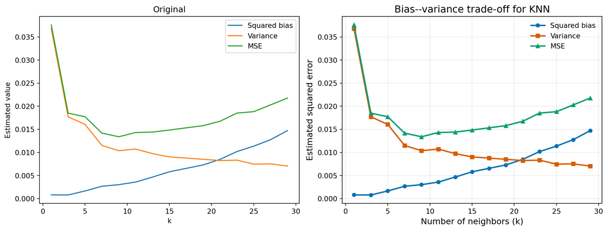

Original (left) and skill-revised (right) versions of the Question 1 plot.

```python
fig, axes = plt.subplots(1, 2, figsize=(12, 4.5), layout="constrained")

for values, label in [(sq_bias, "Squared bias"), (variance, "Variance"), (mse, "MSE")]:
    axes[0].plot(k_q1, values, label=label)
axes[0].set_xlabel("k")
axes[0].set_ylabel("Estimated value")
axes[0].set_title("Original")
axes[0].legend()

colors = ["#0072B2", "#D55E00", "#009E73"]
markers = ["o", "s", "^"]
for values, label, color, marker in zip(
    [sq_bias, variance, mse], ["Squared bias", "Variance", "MSE"], colors, markers
):
    axes[1].plot(
        k_q1, values, label=label, color=color, marker=marker, linewidth=2, markersize=5
    )
axes[1].set_title("Bias--variance trade-off for KNN", fontsize=14)
axes[1].set_xlabel("Number of neighbors (k)", fontsize=12)
axes[1].set_ylabel("Estimated squared error", fontsize=12)
axes[1].tick_params(labelsize=10)
axes[1].grid(alpha=0.25, linewidth=0.8)
axes[1].legend(fontsize=10, frameon=False)

plt.show()
```

I prefer the revised version. The longer axis labels make the quantities clear without surrounding text, markers show the discrete $k$ values, and the colorblind-friendly colors plus different marker shapes do not rely on color alone. The lighter grid helps compare heights without dominating the data. The skill did not change any values or statistical conclusions.

### (c)

The final `SKILL.md` is:

```markdown
---
name: stat432-plot-formatting
description: Improve the presentation of plots for STAT 432 homework only when the user explicitly requests this skill; do not change the statistical analysis or results.
---

# STAT 432 Plot Formatting

Preserve the data, statistical method, and plotted quantities. Improve only the plot's presentation.

- Use balanced margins so titles, axis text, and legends are not clipped; apply a tight or constrained layout when appropriate.
- Write a short, informative title that states the comparison or quantity shown.
- Label both axes with meaningful variable names and units or scales when relevant.
- Use readable tick labels and a light, unobtrusive grid when it helps comparisons.
- Choose a colorblind-friendly palette with clearly distinguishable colors; do not rely on color alone when line styles or markers can help.
- Use consistent sizes: title 13--15 pt, axis labels 11--13 pt, tick and legend text 9--11 pt, lines about 2 pt, and visible markers when observations occur at discrete values.
- In Python, use Matplotlib settings such as `figsize`, `layout="constrained"`, explicit labels, and an accessible palette. In R, use comparable `ggplot2` themes and explicit scales.
- Keep the result suitable for a homework report: uncluttered, legible at normal page width, and free of decorative elements that do not aid interpretation.
```

I kept the skill short and portable. The ranges make its output consistent, while leaving room for the plot type and available page width. The explicit-only policy prevents it from silently changing plots when the goal is statistical debugging or an exact reproduction rather than presentation improvement.